# MICB405 - Differential Gene Analysis

Carlo von Vegesack

2024-11-04

### Setup for first installation

Only execute if you re-installed R or never installed BiocManager

```r
if (!require("BiocManager", quietly = TRUE))
    install.packages("BiocManager")

BiocManager::install("DESeq2")
BiocManager::install("pheatmap")
```

### Normal start

Set the working directory as you need it. In my case I set the working directory to a folder called “final_project”. Inside this folder is a folder called “count_matrix”. “count_matrix” has the ReadsPerGene files. You can see this also in the Load Count Matrix part.

```r
# Load necessary libraries
suppressPackageStartupMessages(library(tidyverse))
suppressPackageStartupMessages(library(DESeq2))
suppressPackageStartupMessages(library(pheatmap))
suppressPackageStartupMessages(library(RColorBrewer))

# Set the working directory
setwd("~/uni/autumn-24/final_project/")
```

## Load Count Matrix

Loading all ReadsPerGene files from the folder “count_matrix”. For the code to run properly it is important to have the ReadsPerGene files named a certain way. I named them treatment_time_replica+normal_file-name (e.g. acetic_45_1ReadsPerGenome.out.tab)

```r
# Specify the subfolder where the gene count files are located
count_files_path <- "count_matrix"

# List all files in the directory that match the naming pattern
files <- list.files(path = count_files_path, pattern = "ReadsPerGene\\.out\\.tab$", full.names = TRUE)

# Function to read and format each file
read_counts <- function(file) {
  counts <- read.table(file, header = FALSE, skip = 4)  # Skip the first 4 lines if they're headers
  counts <- counts[, c(1, 2)]  # Select GeneID and unstranded counts columns

  # Extract sample name from filename (e.g., "acetic_45_1" from "acetic_45_1ReadsPerGene.out.tab")
  sample_name <- sub("ReadsPerGene\\.out\\.tab$", "", basename(file))

  colnames(counts) <- c("GeneID", sample_name)
  return(counts)
}

# Load each file and merge them into a single count matrix
count_list <- lapply(files, read_counts)
count_matrix <- Reduce(function(x, y) merge(x, y, by = "GeneID", all = TRUE), count_list)
rownames(count_matrix) <- count_matrix$GeneID
count_matrix <- count_matrix[, -1]  # Remove the GeneID column
```

## Create Sample Metadata

Check the table if the program correctly matched condition and time to the samples.

```r
# Define sample names matching the columns of the count matrix
sample_names <- c("acetic_45_1", "acetic_45_2", "acetic_120_1", "acetic_120_2",
                  "acetic_200_1", "acetic_200_2",
                  "control_45_1", "control_45_2", "control_120_1", "control_120_2",
                  "control_200_1", "control_200_2")

# Define the metadata for each sample
sample_metadata <- data.frame(
    sample = sample_names,
    condition = c(rep("acetic", 6), rep("control", 6)),
    time_point = c(rep("45", 2), rep("120", 2), rep("200", 2), rep("45", 2), rep("120", 2), rep("200", 2)),
    replicate = rep(1:2, 6)  # Repeat 1 and 2 for each combination of condition and time_point
)
rownames(sample_metadata) <- sample_metadata$sample
# Reorder sample_metadata based on the column names of count_matrix
sample_metadata <- sample_metadata[match(colnames(count_matrix), rownames(sample_metadata)), ]

# Check if meta data is correct
sample_metadata
```

```
##                      sample condition time_point replicate
## acetic_120_1   acetic_120_1    acetic        120         1
## acetic_120_2   acetic_120_2    acetic        120         2
## acetic_200_1   acetic_200_1    acetic        200         1
## acetic_200_2   acetic_200_2    acetic        200         2
## acetic_45_1     acetic_45_1    acetic         45         1
## acetic_45_2     acetic_45_2    acetic         45         2
## control_120_1 control_120_1   control        120         1
## control_120_2 control_120_2   control        120         2
## control_200_1 control_200_1   control        200         1
## control_200_2 control_200_2   control        200         2
## control_45_1   control_45_1   control         45         1
## control_45_2   control_45_2   control         45         2
```

## Results

Create matrix with the count matrix and the meta data. We care about both condition and time point.

```r
# Create DESeq2 dataset
dds <- DESeqDataSetFromMatrix(countData = count_matrix,
                              colData = sample_metadata,
                              design = ~ condition + time_point)

# Run DESeq2 analysis
dds <- DESeq(dds)
```

## Sanity Checks and Quality Assesment

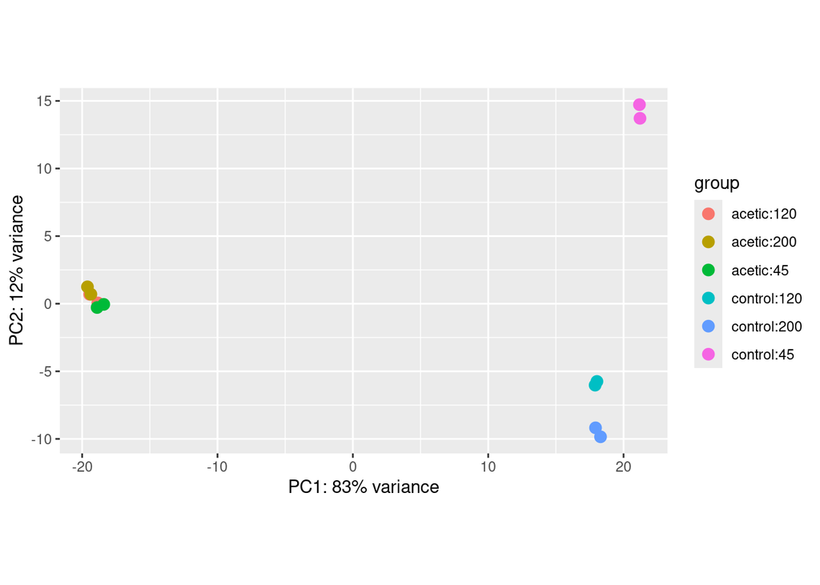

```r
# Perform variance-stabilizing transformation on our count data
vsd <- vst(dds, blind = FALSE)

# Generate a PCA plot with DESeq2's plotPCA function
plotPCA(vsd, intgroup = c("condition", "time_point"))
```

## Heatmap

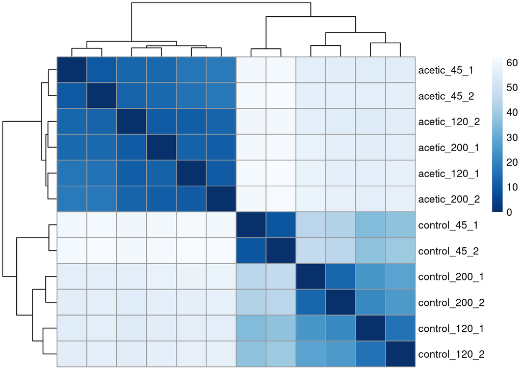

```r
# Calculate distances between samples in our transformed data
sample_dists <- dist(t(assay(vsd)))

# Convert the output to a matrix
sample_dist_matrix <- as.matrix(sample_dists)

# Remove the column names of our matrix
colnames(sample_dist_matrix) <- NULL

# Set the color palette for our heatmap
colours <- colorRampPalette(rev(brewer.pal(9, "Blues")))(255)

# Generate a heatmap using the pheatmap package
pheatmap(sample_dist_matrix,
         clustering_distance_rows = sample_dists,
         clustering_distance_cols = sample_dists,
         col = colours)
```

## Extracting Data from DESeq2 and Filtering

Because of the small difference between time points I decided to only care about acetic vs. control in the downstram analysis.

```r
# Display the names of the results calculated by DESeq2
resultsNames(dds)
```

```
## [1] "Intercept"                   "condition_control_vs_acetic"
## [3] "time_point_200_vs_120"       "time_point_45_vs_120"
```

```r
# Extract the results for our specific comparison
# Replace "condition_treated_vs_control" with the actual result name if different
res <- results(dds, name = "condition_control_vs_acetic") %>% as.data.frame()

# View the first few rows to understand the structure of the results
head(res)
```

```
##         baseMean log2FoldChange     lfcSE       stat    pvalue      padj
## Q0020  80.158705     0.43432792 0.4354498  0.9974236 0.3185589 0.3713192
## Q0045  79.245401     0.44918729 0.3962226  1.1336742 0.2569312 0.3055712
## Q0050 105.738333     0.18232750 0.2223359  0.8200542 0.4121852 0.4676859
## Q0055 391.100063    -0.05238378 0.3537752 -0.1480708 0.8822869 0.9012531
## Q0060   6.253838     0.76300046 0.5589217  1.3651295 0.1722123 0.2124262
## Q0065  16.646718     0.51371134 0.3407498  1.5075910 0.1316592 0.1663175
```

## Data Manipulation and Wrangling with dplyr

```r
# Quick overview of the data
glimpse(res)
```

```
## Rows: 6,477
## Columns: 6
## $ baseMean       <dbl> 8.015871e+01, 7.924540e+01, 1.057383e+02, 3.911001e+02,…
## $ log2FoldChange <dbl> 0.43432792, 0.44918729, 0.18232750, -0.05238378, 0.7630…
## $ lfcSE          <dbl> 0.4354498, 0.3962226, 0.2223359, 0.3537752, 0.5589217, …
## $ stat           <dbl> 0.99742360, 1.13367417, 0.82005423, -0.14807082, 1.3651…
## $ pvalue         <dbl> 0.31855894, 0.25693125, 0.41218519, 0.88228688, 0.17221…
## $ padj           <dbl> 0.37131916, 0.30557122, 0.46768589, 0.90125313, 0.21242…
```

```r
# Remove rows with NA values in any column
res_no_NA <- res %>% drop_na()

# Check the number of rows remaining after filtering out NA values
glimpse(res_no_NA)
```

```
## Rows: 6,320
## Columns: 6
## $ baseMean       <dbl> 8.015871e+01, 7.924540e+01, 1.057383e+02, 3.911001e+02,…
## $ log2FoldChange <dbl> 0.43432792, 0.44918729, 0.18232750, -0.05238378, 0.7630…
## $ lfcSE          <dbl> 0.43544981, 0.39622257, 0.22233590, 0.35377517, 0.55892…
## $ stat           <dbl> 0.99742360, 1.13367417, 0.82005423, -0.14807082, 1.3651…
## $ pvalue         <dbl> 3.185589e-01, 2.569312e-01, 4.121852e-01, 8.822869e-01,…
## $ padj           <dbl> 3.713192e-01, 3.055712e-01, 4.676859e-01, 9.012531e-01,…
```

## Filter for Significantly Differentially Expressed

```r
# Filter to keep only genes with adjusted p-value < 0.05
res_filtered <- res_no_NA %>% filter(padj < 0.05)

# Check the number of rows remaining after this filtering step
glimpse(res_filtered)
```

```
## Rows: 4,485
## Columns: 6
## $ baseMean       <dbl> 1228.95457, 468.88143, 12832.51723, 1473.95366, 817.007…
## $ log2FoldChange <dbl> 0.5674203, 0.8706555, -0.6720238, -0.5889768, 0.3735920…
## $ lfcSE          <dbl> 0.04698885, 0.07105248, 0.11344211, 0.05264117, 0.08167…
## $ stat           <dbl> 12.075637, 12.253696, -5.923936, -11.188521, 4.574203, …
## $ pvalue         <dbl> 1.420600e-33, 1.605096e-34, 3.143263e-09, 4.641122e-29,…
## $ padj           <dbl> 1.452782e-32, 1.696355e-33, 9.100057e-09, 3.985311e-28,…
```

```r
# Further filter for biologically relevant genes (log2 fold change ≥ ±1)
res_filtered_final <- res_filtered %>%
  filter(log2FoldChange <= -1 | log2FoldChange >= 1) %>%
  rownames_to_column("gene_id")  # Convert row names to a "gene_id" column for easy handling

# View the first few rows of the final filtered results
head(res_filtered_final)
```

```
##     gene_id  baseMean log2FoldChange      lfcSE       stat       pvalue
## 1   YAL010C 589.27593      -1.094681 0.05566340 -19.666076 4.211408e-86
## 2   YAL018C  41.93089      -2.244894 0.21350481 -10.514490 7.408017e-26
## 3   YAL022C 939.56395       1.852926 0.11456123  16.174112 7.679692e-59
## 4 YAL034W-A 203.03819       1.016308 0.09664772  10.515591 7.322028e-26
## 5 YAL037C-A  10.78727       2.037850 0.37740473   5.399641 6.677422e-08
## 6   YAL062W 727.91440       1.445619 0.18768829   7.702233 1.337086e-14
##           padj
## 1 2.163911e-84
## 2 5.501606e-25
## 3 1.811032e-57
## 4 5.444143e-25
## 5 1.756193e-07
## 6 5.501550e-14
```

## Top 10 up- and downregulated genes

Here we could check the gene id’s and see whether they match with our hypothesis.

```r
# Select the top 10 upregulated genes (highest log2 fold change)
top10_genes <- res_filtered_final %>%
  arrange(desc(log2FoldChange)) %>%
  head(n = 10)

# View the top 10 upregulated genes
top10_genes
```

```
##      gene_id    baseMean log2FoldChange     lfcSE      stat       pvalue
## 1  YNCG0012W   48.358670       6.600220 0.6267821 10.530326 6.261715e-26
## 2  YNCD0003W   17.743188       5.718919 0.7463664  7.662348 1.825645e-14
## 3  YNCH0009C    6.131798       5.508958 0.8978130  6.135975 8.463860e-10
## 4  YNCD0018W   17.364057       5.321451 0.7076002  7.520420 5.460052e-14
## 5    YOR235W   10.555849       5.296852 0.8070881  6.562916 5.276540e-11
## 6    YAL067C 1844.929415       5.027064 0.6712982  7.488571 6.962756e-14
## 7  YNCJ0002C   10.584031       5.005303 0.7712199  6.490111 8.577290e-11
## 8  YNCP0008C   14.542138       4.903487 0.6480308  7.566751 3.826741e-14
## 9  YNCO0019W   12.441266       4.893970 0.6825649  7.169970 7.501399e-13
## 10 YNCN0006W    3.762325       4.851830 0.9258693  5.240297 1.603183e-07
##            padj
## 1  4.672260e-25
## 2  7.400945e-14
## 3  2.551666e-09
## 4  2.155374e-13
## 5  1.724288e-10
## 6  2.723058e-13
## 7  2.768563e-10
## 8  1.525868e-13
## 9  2.754726e-12
## 10 4.047427e-07
```

```r
# Select the top 10 downregulated genes (lowest log2 fold change)
bot10_genes <- res_filtered_final %>%
  arrange(log2FoldChange) %>%
  head(n = 10)

# View the top 10 downregulated genes
bot10_genes
```

```
##      gene_id    baseMean log2FoldChange     lfcSE       stat        pvalue
## 1    YOL161C   12.447096      -4.845842 0.6843032  -7.081426  1.426789e-12
## 2    YER067W 1948.223506      -3.896405 0.1012205 -38.494229  0.000000e+00
## 3    YLL030C    3.509455      -3.703489 0.9119134  -4.061229  4.881503e-05
## 4    YDL241W  607.799978      -3.582524 0.1248433 -28.696164 4.259849e-181
## 5    YER011W  569.097208      -3.564827 0.2284454 -15.604723  6.760260e-55
## 6    YBR018C   86.577942      -3.563948 0.2510831 -14.194293  9.938322e-46
## 7    YKL224C    2.599642      -3.496193 0.9926943  -3.521923  4.284291e-04
## 8    YCL064C 2396.692056      -3.482438 0.1264907 -27.531183 7.435487e-167
## 9  YBL108C-A    4.864796      -3.355556 0.7338213  -4.572715  4.814439e-06
## 10   YGL138C   44.870949      -3.154258 0.2812302 -11.215927  3.405973e-29
##             padj
## 1   5.167511e-12
## 2   0.000000e+00
## 3   9.781580e-05
## 4  1.076890e-178
## 5   1.414730e-53
## 6   1.570255e-44
## 7   7.703193e-04
## 8  1.468509e-164
## 9   1.065380e-05
## 10  2.944699e-28
```

## Volcano plot

Volcano plot for acetic vs. control. Problematic with the volcano plot is that some data points are cut up. The Reason for that is that the p-values for certain genes are very very small in comparison to other genes. You could cap the low p-values but I don’t know if I like it to “missrepresent” the data. ### Prepare data for volcano plot

```r
# Convert the results to a data frame
dat <- as.data.frame(res_filtered_final)

# Label the genes based on log2FoldChange and padj values
labelled_dat <- dat %>%
  mutate(up_down = case_when(
    padj < 0.05 & log2FoldChange > 2 ~ "UP",    # Upregulated genes
    padj < 0.05 & log2FoldChange < -2 ~ "DOWN",  # Downregulated genes
    TRUE ~ "NONE"                                # Not significantly different
  ))
```

## ggplot

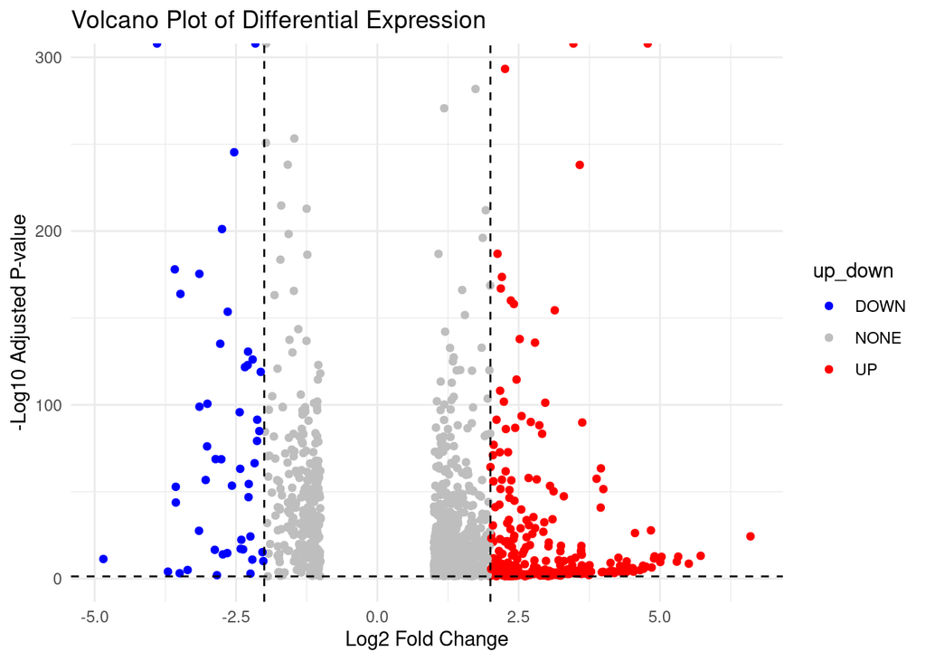

```r
# Create the volcano plot
labelled_dat %>%
  ggplot(aes(x = log2FoldChange, y = -log10(padj), color = up_down)) +
  geom_point() +
  geom_hline(yintercept = -log10(0.05), linetype = "dashed") +  # Threshold line for significance
  geom_vline(xintercept = c(-2, 2), linetype = "dashed") +      # Thresholds for fold change
  labs(title = "Volcano Plot of Differential Expression",
       x = "Log2 Fold Change",
       y = "-Log10 Adjusted P-value") +
  scale_color_manual(values = c("UP" = "red", "DOWN" = "blue", "NONE" = "gray")) +
  theme_minimal()
```

## Barplot

We could use the barplot to show that the majority of genes are upregulated. Especially, for the genes with the highest difference between treatments. ### Create new column

```r
# Prepare the data for the bar plot
labelled_dat2 <- labelled_dat %>%
  mutate(
    abs_l2fc = abs(log2FoldChange),  # Calculate the absolute value of log2 fold change
    up_down = if_else(log2FoldChange <= 0, "DOWN", "UP")  # Label genes as UP or DOWN
  ) %>%
  mutate(
    l2fc = case_when(  # Bin genes based on log2 fold change
      abs_l2fc >= 4 ~ ">4",
      abs_l2fc >= 3 ~ "3",
      abs_l2fc >= 2 ~ "2",
      abs_l2fc >= 1 ~ "1",
      TRUE ~ "<1"
    )
  )
```

### Plot the Bar Graph

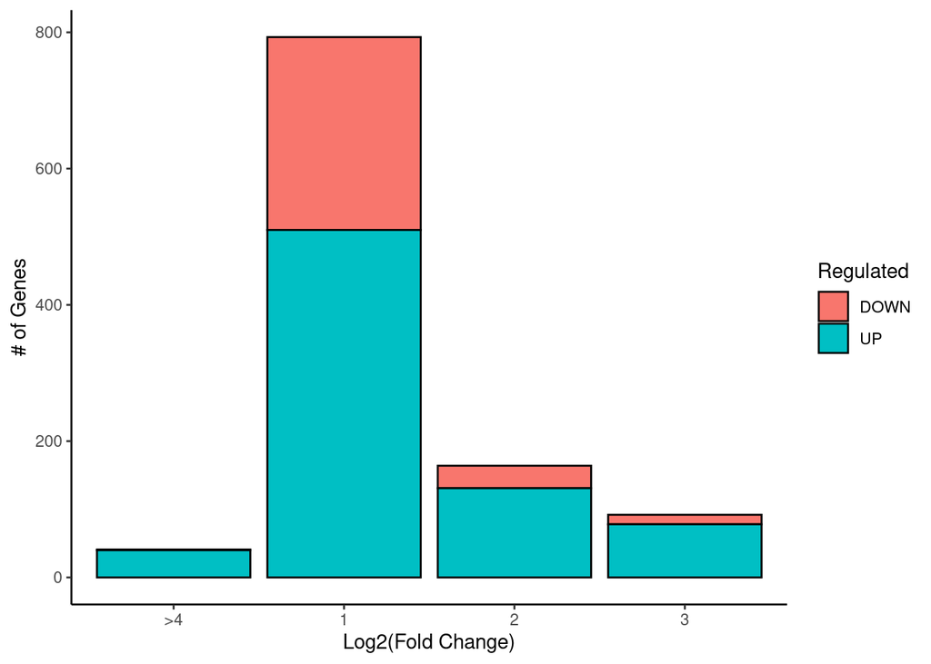

```r
# Initial bar plot
labelled_dat2 %>%
  ggplot(aes(x = l2fc, fill = up_down)) +
  geom_bar(color = "black") +
  theme_classic() +
  labs(x = "Log2(Fold Change)", y = "# of Genes", fill = "Regulated")
```

### Organize X-Axis

```r
# Convert `l2fc` into a factor and specify the desired order
labelled_dat2$l2fc <- factor(labelled_dat2$l2fc, levels = c("<1", "1", "2", "3", ">4"))
```

### Plotting with ordered factors

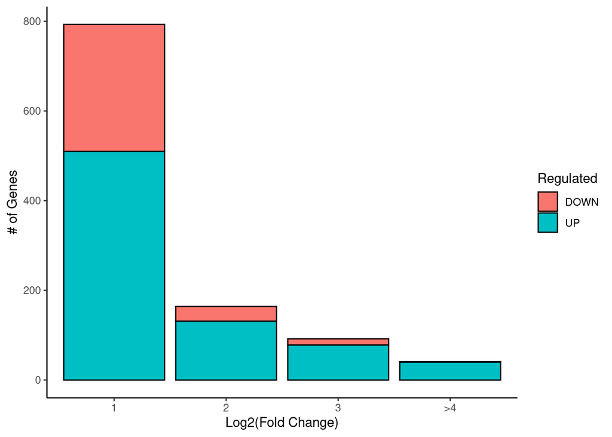

```r
# Final bar plot with ordered x-axis
ggplot(labelled_dat2, aes(x = l2fc, fill = up_down)) +
  geom_bar(color = "black") +
  theme_classic() +
  labs(x = "Log2(Fold Change)", y = "# of Genes", fill = "Regulated")
```